# Arabidopsis genomic prediction

This notebook includes a trial run of GBLUP using two methods: rrBLUP and a likelihood based genomic feature model. The trait in this case is total free amino acid content in dry Arabidopsis seeds, which has an estimated predictive accuracy of ~0.4 using standard GBLUP through GAPIT.

## Project goal

- partition genomic variance into SNP categories based on metabolic pathway annotations, statistics of interest include:
  - proportion of genomic variance explained (h^2)
  - likelihood ratio test (base GBLUP model where all SNPs contribute equally vs. partitioning kinship matrices)
  - predictive accuracy (expect higher if a causal SNP is in the genomic feature set)
- want to model after Edwards et al. (2015) Partitioning of genomic variance reveals biological pathways associated with udder health and milk production traits in dairy cattle

## Methods

- **GAPIT**
  - ran GBLUP model using all SNPs, a subset of SNPs in the amino acid pathway (7667 SNPs), and 1000 ‘control subsets’ (7667 SNPs each)
  - compared predictive accuracies
- **Genomic feature model**
  - follows approaches in several papers (Edwards et al. 2015, Edwards et al. 2016)
  - implemented in `qgg` package
  - partitions genomic variance into ‘genomic features’, in our case annotation categories
  - running into issues
- **LDAK** (dougspeed.com/ldak/)
  - another method to estimate contribution of SNP subsets to heritability
  - model is running successfully (yay) but need to figure out cross-validation to estimate predictive ability

## Issues/questions

**Major holdup is troubleshooting genomic feature model and cross validation**

## rrBLUP

Run standard GBLUP using the rrBLUP package (ridge regression BLUP) - using as a check to compare with genomic feature model

```r
# read in and format SNP data (must be {-1, 0, 1} format)
plink_file <- read.plink(bed = "data/input_nomissing.bed",
                   bim = "data/input_nomissing.bim",
                   fam = "data/input_nomissing.fam")
W <- coerce(plink_file$genotypes, to = "character")
```

```
direct use of coerce() is deprecated:  use as(from, class(to)) instead
```

```r
W[W == "A/A"] <- -1 # homozygous AA
W[W == "A/B"] <- 0 # heterozygote AB
W[W == "B/B"] <- 1 # homozygous BB
mode(W) <- "numeric"
rownames(W) <- paste0("A", rownames(W)) # append A to rownames
W[1:10,1:10]
```

```
     S1 S2 S3 S4 S5 S6 S7 S8 S9 S10
A1    1  1  1  1  1  1  1  1  1   1
A2    1 -1  1 -1  1  1 -1 -1  1  -1
A23  -1  1 -1 -1 -1  1  1  1 -1  -1
A66   1 -1  1 -1  1  1  1 -1  1  -1
A81   1 -1  1 -1  1 -1  1 -1  1  -1
A91  -1  1 -1 -1  1  1  1  1 -1  -1
A94   1 -1  1 -1  1  1  1 -1  1  -1
A96   1 -1  1 -1  1 -1  1 -1  1  -1
A116  1 -1  1 -1  1  1  1 -1  1  -1
A126 -1  1 -1 -1  1  1  1  1 -1  -1
```

```r
# read in phenotype file as matrix
pheno <- as.matrix(read.csv("/home/turnersa/Documents/AA-GenomicPrediction/data/input_files/phenotypes.csv"))
rownames(pheno) <- pheno[,1]
pheno <- pheno[,-1]
mode(pheno) <- "numeric"
pheno[1:5,1:5]
```

```
          ala      arg      asp      gln      glu
A1   1.552852 1.159600 1.135215 2.668638 1.077452
A116 1.558380 1.147520 1.209282 2.590687 1.080312
A126 1.037377 1.094559 1.148481 2.405929 1.087352
A149 1.305834 1.106587 1.156504 2.642795 1.093395
A166 1.250325 1.113160 1.122352 2.641558 1.086976
```

```r
dim(pheno)
```

```
[1] 312  54
```

```r
# remove individuals with missing phenotypic data from genotype matrix
dim(W)
```

```
[1]    312 213619
```

```r
W <- W[rownames(W)%in%rownames(pheno),]
dim(W)
```

```
[1]    312 213619
```

Cross-validation script adapted from: https://figshare.com/articles/R_Script_for_cross-validation_/5712208

Not sure this is quite the type of cross-validation we should aim for - want 3 fold with one fold hold out; currently we are just randomly sampling 2/3 for the training set and 1/3 for the validation set and repeating this 100x without any hold out.

Other note: could be MUCH more efficient; consider scaling up on server but this works for now

```r
# impute missing markers using A.mat - not necessary (no missing markers in this data)
# impute <- A.mat(W, max.missing = 0.5, impute.method = "mean", return.imputed = TRUE)
# sum(is.na(impute$imputed))
# markers_impute <- impute$imputed
trainsize <- 70 # default for rrBLUP - almost 3-fold CV? not quite but kind of
iter <- 100 # number of iterations for CV
# establish training and testing sets
N <- rownames(W)
# may need to modify this part (rounding can be tricky, may have < or > 312 individuals total)
trainset <- round(length(N) * (trainsize/100))
testset <- round(length(N) - trainset)
# matrix to hold results of each iteration
rrblup_res <- matrix(NA, iter, 2) # 100 iterations, two columns for predictive accuracy and coefficients
# loop through iterations (for Total free amino acids)
train <- matrix(NA, trainset, iter)
test <- matrix(NA, testset, iter)
# not sure about sampling procedure - would be better to do 10 fold and this is not quite right I think?
for (i in 1:iter) {
  train[,i] <- sample(N, size = trainset, replace = FALSE)
  test[,i] <- setdiff(N, train[,i])
  # use above to pull out the records correpsonding to these (pheno and geno)
  geno_train <- W[train[,i],]
  geno_test <- W[test[,i],]
  pheno_train <- pheno[train[,i], "Total"]
  pheno_test <- pheno[test[,i], "Total"]

  # generate marker effects
  mxslv <-  mixed.solve(pheno_train, Z = geno_train, K=NULL, SE=FALSE, return.Hinv=FALSE)
  TPr <- mxslv$u # BLUPs
  eff <- as.matrix(TPr)

  # predict in the test set
  pred_test <- geno_test %*% eff # predictions for test set
  predictions <- pred_test + as.vector(mxslv$beta) # predictions + mean for test set

  # predictive ability
  pa <- cor(predictions, pheno_test, use = "complete")
  # caluclate the bias by regressing the phenotypes (y) on the GEBVs (x)
  reg <- lm(pheno_test ~ predictions)

  # extract the predictionsHD coefficient from the reg object
  coef <- summary(reg)$coefficients[2,1]
  # Store the results
  rrblup_res[i,1] <- pa
  rrblup_res[i,2] <- coef
}
colnames(rrblup_res) <- c("pa", "coef")
rrblup_res <- as.data.frame(rrblup_res)
cat("mean predictive accuracy for total free amino acids (rrBLUP):", mean(rrblup_res$pa))
```

```
mean predictive accuracy for total free amino acids (rrBLUP): 0.3840235
```

## Genomic feature prediction simulation

Likelihood method

Starting with a simulation provided in the qgg package documentation for function `gfm`

### Step 1: simulate genomic relationship matrix and phenotype

```r
# genomic feature model with likelihood method
# simulate genomic relationship matrix
W_sim <- matrix(rnorm(2000000), ncol = 10000)
colnames(W_sim) <- as.character(1:ncol(W_sim))
W_sim[1:5,1:5]
```

```
              1          2          3          4          5
[1,]  1.6238194  1.5708049  1.5766945 -1.5222202 -0.1635143
[2,] -0.2866721 -1.1669186  1.0196929 -0.9710933 -1.0763758
[3,] -0.3465282 -0.7456260 -0.7507855 -0.6488628  1.0845337
[4,]  0.9714804  1.1305632 -1.1750243  1.3273000 -0.1996051
[5,] -0.5026572  0.2038272  0.5466153 -1.4198934 -0.3373763
```

```r
# simulate phenotype
y <- rowSums(W_sim[,1:10]) + rowSums(W_sim[, 1001:1010]) + rnorm(nrow(W_sim)) # true model
```

### Step 2: define model and genomic feature lists

```r
# simple example
data <- data.frame(y = y, mu = 1)
fm <- y ~ mu
# genomic feature lists
setsGB <- list(A = colnames(W_sim)) # GBLUP model
setsGF <- list(C1 = colnames(W_sim)[1:1000], C2 = colnames(W_sim)[1001:2000], C3 = colnames(W_sim)[2000:10000]) # all markers split into sets
setsGT <- list(C1 = colnames(W_sim)[1:10], C2 = colnames(W_sim)[1001:1010], C3 = colnames(W_sim)[1:10000]) # true model
```

### Step 3: run model with 3 fold cross validation & 100 replications

```r
cat("mean predictive accuracy for simulatino (genomic feature GBLUP):", mean(fitGB$pa), "\n")
```

```
mean predictive accuracy for simulatino (genomic feature GBLUP): 0.04019415
```

```r
cat("mean predictive accuracy for simulation (genomic feature model):", mean(fitGF$pa), "\n")
```

```
mean predictive accuracy for simulation (genomic feature model): 0.2427046
```

```r
cat("mean predictive accuracy for simulation (genomic feature true model):", mean(fitGT$pa))
```

```
mean predictive accuracy for simulation (genomic feature true model): 0.9712476
```

## Genomic feature prediction for real data

**Notes**

- the Glist function works fine, but cannot retrieve the genomic relationship matrix using getW (only returns SNP names)
- predictive ability is low when running a standard GBLUP model (our null model) using this method

```r
cat("mean predictive accuracy for total free amino acids (genomic feature GBLUP):", mean(res_gfm$pa))
```

```
mean predictive accuracy for total free amino acids (genomic feature GBLUP): 0.1084694
```

## What the heck is going on?

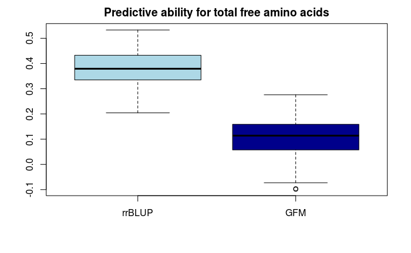

```r
results <- cbind(rrblup_res$pa, res_gfm$pa)
colnames(results) <- c("rrBLUP", "GFM")
results <- as.data.frame(results)
results_long <- gather(results)
results_long$key <- factor(results_long$key, levels = c("rrBLUP", "GFM"))
boxplot(results_long$value ~ results_long$key, main = "Predictive ability for total free amino acids",
        col = c("lightblue", "darkblue"))
```